# Lecture 10 - Class Activity: Regression and Linear Models

Author

Bill Perry

# Class Activity 10: Advanced Linear Regression and Model II Regression

## Introduction

We’ll work with the same datasets from the lecture to practice these advanced concepts.

# **Part 1:** Load Required Packages and Data

```r
# Load required packages
library(tidyverse)  # For data manipulation and visualization
library(patchwork)  # For combining plots
library(car)        # For regression diagnostics
library(broom)      # For tidy model output
library(smatr)      # For Model II regression
library(lmodel2)    # Alternative package for Model II regression
library(lmtest)     # For assumption tests
library(MASS)       # For robust regression
library(boot)       # For bootstrapping

# Set seed for reproducible results
set.seed(123)

# Create the datasets from the lecture
# Lion data - predicting age from nose blackness
lion_data <- tibble(
  proportion_black = c(0.21, 0.14, 0.11, 0.13, 0.12, 0.13, 0.12, 0.18, 0.23, 0.22,
                      0.20, 0.17, 0.15, 0.27, 0.26, 0.21, 0.30, 0.42, 0.43, 0.59,
                      0.60, 0.72, 0.29, 0.10, 0.48, 0.44, 0.34, 0.37, 0.34, 0.74, 0.79, 0.51),
  age_years = c(1.1, 1.5, 1.9, 2.2, 2.6, 3.2, 3.2, 2.9, 2.4, 2.1,
               1.9, 1.9, 1.9, 1.9, 2.8, 3.6, 4.3, 3.8, 4.2, 5.4,
               5.8, 6.0, 3.4, 4.0, 7.3, 7.3, 7.8, 7.1, 7.1, 13.1, 8.8, 5.4)
)

# Fish allometric data - both X and Y have measurement error
fish_data <- tibble(
  length_mm = runif(40, 180, 320),
  mass_g = 0.00001 * length_mm^3 * runif(40, 0.9, 1.1)
)

# Create example data where both X and Y have error (for Model II demonstration)
n <- 50
x_true <- rnorm(n, mean = 10, sd = 2)
x_observed <- x_true + rnorm(n, 0, 1)  # X has measurement error
y_observed <- 2 + 3 * x_true + rnorm(n, mean = 0, sd = 2)  # Y depends on true X
model_comparison_data <- tibble(x = x_observed, y = y_observed)
```

**New Packages for Advanced Regression**

- **smatr**: Standardized Major Axis regression (Model II)
- **lmodel2**: Multiple Model II regression methods
- **lmtest**: Tests for regression assumptions
- **MASS**: Robust regression methods
- **boot**: Bootstrap confidence intervals

# **Part 2:** Analysis of Variance in Regression

**Linear Regression ANOVA: Data Types and Assumptions**

**Data Types Required:**

- **X variable (predictor)**: Continuous numerical

- **Y variable (response)**: Continuous numerical

**Key Concept:**

- - Total variation in Y is partitioned into:
  - - **SS_regression**: Variation explained by X
  - - **SS_residual**: Unexplained variation (error)
  - - **SS_total** = SS_regression + SS_residual

**Assumptions:**

- - Linearity between X and Y
- - Independence of observations
- - Homoscedasticity (constant variance)
- - Normality of residuals
- - No influential outliers

## Understanding Variance Partitioning

```r
# Fit the lion regression model
lion_model <- lm(age_years ~ proportion_black, data = lion_data)

# Get the ANOVA table
anova_table <- anova(lion_model)
print("ANOVA Table for Lion Age ~ Nose Blackness:")
```

```
[1] "ANOVA Table for Lion Age ~ Nose Blackness:"
```

```r
print(anova_table)
```

```
Analysis of Variance Table

Response: age_years
                 Df  Sum Sq Mean Sq F value    Pr(>F)
proportion_black  1 138.544 138.544   49.75 7.677e-08 ***
Residuals        30  83.543   2.785
---
Signif. codes:  0 '***' 0.001 '**' 0.01 '*' 0.05 '.' 0.1 ' ' 1
```

```r
# Calculate variance components manually
ss_total <- sum((lion_data$age_years - mean(lion_data$age_years))^2)
ss_residual <- sum(residuals(lion_model)^2)
ss_regression <- ss_total - ss_residual

print("\nVariance Partitioning:")
```

```
[1] "\nVariance Partitioning:"
```

```r
print(paste("SS Total:", round(ss_total, 2)))
```

```
[1] "SS Total: 222.09"
```

```r
print(paste("SS Regression:", round(ss_regression, 2),
            "(", round(100*ss_regression/ss_total, 1), "%)"))
```

```
[1] "SS Regression: 138.54 ( 62.4 %)"
```

```r
print(paste("SS Residual:", round(ss_residual, 2),
            "(", round(100*ss_residual/ss_total, 1), "%)"))
```

```
[1] "SS Residual: 83.54 ( 37.6 %)"
```

```r
# Calculate R-squared
r_squared <- ss_regression / ss_total
print(paste("R-squared:", round(r_squared, 4)))
```

```
[1] "R-squared: 0.6238"
```

## Visualizing Variance Components

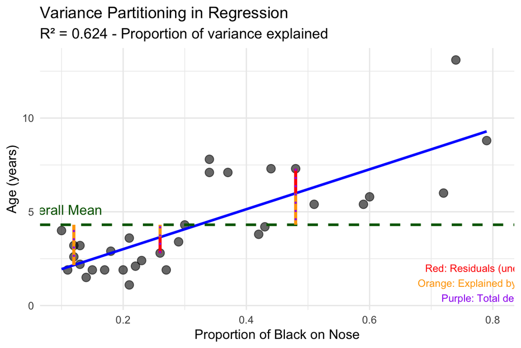

```r
# Create a detailed plot showing variance components
lion_data$predicted <- predict(lion_model)
mean_age <- mean(lion_data$age_years)

# Select a few points to illustrate different components
example_points <- c(5, 15, 25)

variance_plot <- ggplot(lion_data, aes(x = proportion_black, y = age_years)) +
  geom_point(size = 3, alpha = 0.6) +
  geom_smooth(method = "lm", se = FALSE, color = "blue", size = 1) +
  geom_hline(yintercept = mean_age, linetype = "dashed", color = "darkgreen", size = 1) +

  # Add variance components for example points
  geom_segment(data = lion_data[example_points,],
               aes(x = proportion_black, y = age_years,
                   xend = proportion_black, yend = predicted),
               color = "red", size = 1.2) +
  geom_segment(data = lion_data[example_points,],
               aes(x = proportion_black, y = predicted,
                   xend = proportion_black, yend = mean_age),
               color = "orange", size = 1.2) +
  geom_segment(data = lion_data[example_points,],
               aes(x = proportion_black, y = age_years,
                   xend = proportion_black, yend = mean_age),
               color = "purple", size = 0.8, linetype = "dotted") +

  # Add annotations
  annotate("text", x = 0.1, y = mean_age + 0.8,
           label = "Overall Mean", color = "darkgreen", size = 4) +
  annotate("text", x = 0.8, y = 2,
           label = "Red: Residuals (unexplained)", color = "red", size = 3) +
  annotate("text", x = 0.8, y = 1.2,
           label = "Orange: Explained by regression", color = "orange", size = 3) +
  annotate("text", x = 0.8, y = 0.4,
           label = "Purple: Total deviation", color = "purple", size = 3) +

  labs(title = "Variance Partitioning in Regression",
       subtitle = paste("R² =", round(r_squared, 3), "- Proportion of variance explained"),
       x = "Proportion of Black on Nose",
       y = "Age (years)") +
  theme_minimal() +
  theme(plot.subtitle = element_text(size = 12))
variance_plot
```

**Activity 1: Understanding Variance Partitioning**

From the analysis above, answer these questions:

1. **Total Variance**: What is the total sum of squares for lion age?
   - Your answer: _________________________________
2. **Explained Variance**: What percentage of the total variance is explained by nose blackness?
   - Your answer: _________________________________
3. **F-statistic**: What is the F-statistic value and what does it test?
   - Your answer: _________________________________
4. **Interpretation**: In biological terms, what does the R² value tell us about aging in lions?
   - Your answer: _________________________________

# **Part 3:** Testing Regression Assumptions in Detail

**Regression Assumptions: Detailed Testing**

**Critical Assumptions to Test:**

- - **Linearity**: Relationship between X and Y is linear
- - **Normality**: Residuals are normally distributed
- - **Homoscedasticity**: Variance of residuals is constant
- - **Independence**: Observations are independent
- - **No influential outliers**: No single point dominates the relationship

**Consequences of Violations:**

- - Biased parameter estimates
- - Incorrect standard errors
- - Invalid hypothesis tests
- - Poor predictions

## Comprehensive Assumption Testing

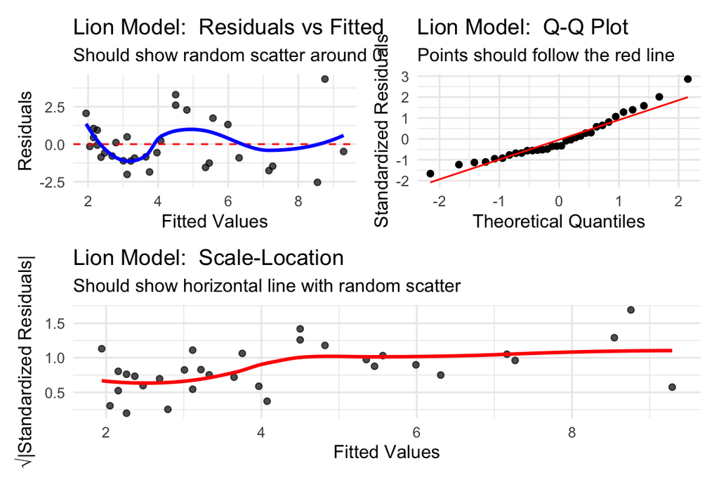

```r
# 1. Test for Linearity
# Create residual plots
residual_plots <- function(model, data, title_prefix = "") {
  # Get residuals and fitted values
  data$residuals <- residuals(model)
  data$fitted <- fitted(model)
  data$std_residuals <- rstandard(model)

  # Residuals vs Fitted (linearity and homoscedasticity)
  p1 <- ggplot(data, aes(x = fitted, y = residuals)) +
    geom_point(alpha = 0.7) +
    geom_hline(yintercept = 0, color = "red", linetype = "dashed") +
    geom_smooth(se = FALSE, color = "blue") +
    labs(title = paste(title_prefix, "Residuals vs Fitted"),
         subtitle = "Should show random scatter around 0",
         x = "Fitted Values", y = "Residuals") +
    theme_minimal()

  # Q-Q plot for normality
  p2 <- ggplot(data, aes(sample = std_residuals)) +
    stat_qq() + stat_qq_line(color = "red") +
    labs(title = paste(title_prefix, "Q-Q Plot"),
         subtitle = "Points should follow the red line",
         x = "Theoretical Quantiles", y = "Standardized Residuals") +
    theme_minimal()

  # Scale-Location plot (homoscedasticity)
  p3 <- ggplot(data, aes(x = fitted, y = sqrt(abs(std_residuals)))) +
    geom_point(alpha = 0.7) +
    geom_smooth(se = FALSE, color = "red") +
    labs(title = paste(title_prefix, "Scale-Location"),
         subtitle = "Should show horizontal line with random scatter",
         x = "Fitted Values", y = "√|Standardized Residuals|") +
    theme_minimal()

  return(list(p1, p2, p3))
}

# Create diagnostic plots for lion model
lion_plots <- residual_plots(lion_model, lion_data, "Lion Model: ")
(lion_plots[[1]] + lion_plots[[2]]) / lion_plots[[3]]
```

## Formal Statistical Tests for Assumptions

```r
# Test 1: Normality of residuals (Shapiro-Wilk test)
shapiro_test <- shapiro.test(residuals(lion_model))
print("1. NORMALITY TEST (Shapiro-Wilk):")
```

```
[1] "1. NORMALITY TEST (Shapiro-Wilk):"
```

```r
print(paste("H0: Residuals are normally distributed"))
```

```
[1] "H0: Residuals are normally distributed"
```

```r
print(paste("p-value:", round(shapiro_test$p.value, 4)))
```

```
[1] "p-value: 0.0692"
```

```r
print(paste("Interpretation:", ifelse(shapiro_test$p.value > 0.05,
                                    "Residuals appear normal (p > 0.05)",
                                    "Residuals may not be normal (p ≤ 0.05)")))
```

```
[1] "Interpretation: Residuals appear normal (p > 0.05)"
```

```r
print("")
```

```
[1] ""
```

```r
# Test 2: Homoscedasticity (Breusch-Pagan test)
bp_test <- bptest(lion_model)
print("2. HOMOSCEDASTICITY TEST (Breusch-Pagan):")
```

```
[1] "2. HOMOSCEDASTICITY TEST (Breusch-Pagan):"
```

```r
print(paste("H0: Variance is constant (homoscedastic)"))
```

```
[1] "H0: Variance is constant (homoscedastic)"
```

```r
print(paste("p-value:", round(bp_test$p.value, 4)))
```

```
[1] "p-value: 0.0086"
```

```r
print(paste("Interpretation:", ifelse(bp_test$p.value > 0.05,
                                    "Variance appears constant (p > 0.05)",
                                    "Variance may not be constant (p ≤ 0.05)")))
```

```
[1] "Interpretation: Variance may not be constant (p ≤ 0.05)"
```

```r
print("")
```

```
[1] ""
```

```r
# Test 3: Influential observations (Cook's Distance)
cooks_d <- cooks.distance(lion_model)
influential_threshold <- 4/length(lion_data$age_years)
influential_points <- which(cooks_d > influential_threshold)

print("3. INFLUENTIAL OBSERVATIONS (Cook's Distance):")
```

```
[1] "3. INFLUENTIAL OBSERVATIONS (Cook's Distance):"
```

```r
print(paste("Threshold for influence:", round(influential_threshold, 4)))
```

```
[1] "Threshold for influence: 0.125"
```

```r
print(paste("Number of influential points:", length(influential_points)))
```

```
[1] "Number of influential points: 2"
```

```r
if(length(influential_points) > 0) {
  print(paste("Influential points:", paste(influential_points, collapse = ", ")))
}
```

```
[1] "Influential points: 22, 30"
```

```r
print("")
```

```
[1] ""
```

```r
# Test 4: Linearity (Rainbow test)
rainbow_test <- raintest(lion_model)
print("4. LINEARITY TEST (Rainbow test):")
```

```
[1] "4. LINEARITY TEST (Rainbow test):"
```

```r
print(paste("H0: Relationship is linear"))
```

```
[1] "H0: Relationship is linear"
```

```r
print(paste("p-value:", round(rainbow_test$p.value, 4)))
```

```
[1] "p-value: 4e-04"
```

```r
print(paste("Interpretation:", ifelse(rainbow_test$p.value > 0.05,
                                    "Relationship appears linear (p > 0.05)",
                                    "Relationship may be non-linear (p ≤ 0.05)")))
```

```
[1] "Interpretation: Relationship may be non-linear (p ≤ 0.05)"
```

## Outlier and Influence Analysis

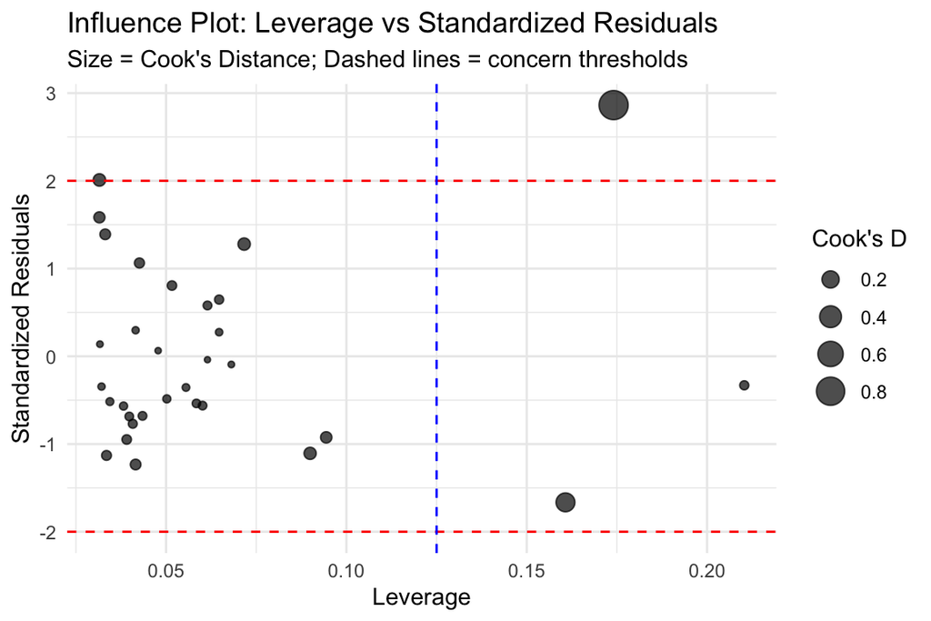

```r
# Create influence plot
lion_data$cooks_d <- cooks.distance(lion_model)
lion_data$leverage <- hatvalues(lion_model)
lion_data$std_residuals <- rstandard(lion_model)

influence_plot <- ggplot(lion_data, aes(x = leverage, y = std_residuals)) +
  geom_point(aes(size = cooks_d), alpha = 0.7) +
  geom_hline(yintercept = c(-2, 2), linetype = "dashed", color = "red") +
  geom_vline(xintercept = 2*2/nrow(lion_data), linetype = "dashed", color = "blue") +
  labs(title = "Influence Plot: Leverage vs Standardized Residuals",
       subtitle = "Size = Cook's Distance; Dashed lines = concern thresholds",
       x = "Leverage",
       y = "Standardized Residuals",
       size = "Cook's D") +
  theme_minimal()

influence_plot
```

**Activity 2: Assumption Testing Results**

Based on the diagnostic plots and formal tests:

1. **Linearity**: Is the relationship linear? (Check residuals vs fitted plot and Rainbow test)
   - Your answer: _________________________________
2. **Normality**: Are residuals normally distributed? (Check Q-Q plot and Shapiro test)
   - Your answer: _________________________________
3. **Homoscedasticity**: Is variance constant? (Check Scale-Location plot and BP test)
   - Your answer: _________________________________
4. **Influential Points**: Are there concerning influential observations?
   - Your answer: _________________________________
5. **Overall Assessment**: Can we trust the regression results?
   - Your answer: _________________________________

# **Part 4:** Model II Regression - When X Has Error

**Model II Regression: Data Types and When to Use**

**Data Types Required:**

- **X variable**: Continuous numerical (with measurement error)

- **Y variable**: Continuous numerical (with measurement error)

**When to Use Model II:**

- Both X and Y have measurement error

- Neither variable is clearly “dependent” or “independent”

- Goal is to estimate the true structural relationship

- Studying allometric relationships or scaling laws

**Types of Model II Regression:**

- **MA (Major Axis)**: Same units for X and Y

- **SMA (Standardized Major Axis)**: Different units for X and Y

- **RMA (Reduced Major Axis)**: General purpose

**Assumptions:**

- Linear relationship between true X and Y values

- Errors in X and Y are normally distributed

- Error variances are known or can be estimated

## Comparing Model I vs Model II Regression

```r
# Fit different regression models to data with X and Y error
print("COMPARING REGRESSION METHODS")
```

```
[1] "COMPARING REGRESSION METHODS"
```

```r
print("=============================")
```

```
[1] "============================="
```

```r
# Model I: Ordinary Least Squares (OLS)
model_ols <- lm(y ~ x, data = model_comparison_data)
ols_slope <- coef(model_ols)[2]
ols_intercept <- coef(model_ols)[1]

print("MODEL I (OLS) RESULTS:")
```

```
[1] "MODEL I (OLS) RESULTS:"
```

```r
print(paste("Slope:", round(ols_slope, 3)))
```

```
[1] "Slope: 2.302"
```

```r
print(paste("Intercept:", round(ols_intercept, 3)))
```

```
[1] "Intercept: 9.22"
```

```r
print("")
```

```
[1] ""
```

```r
# Model II: Standardized Major Axis (SMA)
model_sma <- sma(y ~ x, data = model_comparison_data, method = "SMA")
sma_slope <- coef(model_sma)[2]
sma_intercept <- coef(model_sma)[1]

print("MODEL II - SMA RESULTS:")
```

```
[1] "MODEL II - SMA RESULTS:"
```

```r
print(paste("Slope:", round(sma_slope, 3)))
```

```
[1] "Slope: 2.945"
```

```r
print(paste("Intercept:", round(sma_intercept, 3)))
```

```
[1] "Intercept: 2.766"
```

```r
print("")
```

```
[1] ""
```

```r
# Model II: Major Axis (MA)
model_ma <- sma(y ~ x, data = model_comparison_data, method = "MA")
ma_slope <- coef(model_ma)[2]
ma_intercept <- coef(model_ma)[1]

print("MODEL II - MA RESULTS:")
```

```
[1] "MODEL II - MA RESULTS:"
```

```r
print(paste("Slope:", round(ma_slope, 3)))
```

```
[1] "Slope: 3.609"
```

```r
print(paste("Intercept:", round(ma_intercept, 3)))
```

```
[1] "Intercept: -3.91"
```

```r
print("")
```

```
[1] ""
```

```r
# Model II: Reduced Major Axis using lmodel2
model_rma <- lmodel2(y ~ x, data = model_comparison_data)
```

```
RMA was not requested: it will not be computed.
```

```
No permutation test will be performed
```

```r
rma_results <- model_rma$regression.results
rma_slope <- rma_results$Slope[rma_results$Method == "RMA"]
rma_intercept <- rma_results$Intercept[rma_results$Method == "RMA"]

print("MODEL II - RMA RESULTS:")
```

```
[1] "MODEL II - RMA RESULTS:"
```

```r
print(paste("Slope:", round(rma_slope, 3)))
```

[output not shown]

```r
print(paste("Intercept:", round(rma_intercept, 3)))
```

[output not shown]

```r
print("")
```

```
[1] ""
```

```r
print("TRUE RELATIONSHIP (for comparison):")
```

```
[1] "TRUE RELATIONSHIP (for comparison):"
```

```r
print("Slope: 3.0, Intercept: 2.0")
```

```
[1] "Slope: 3.0, Intercept: 2.0"
```

## Visualizing Different Regression Methods

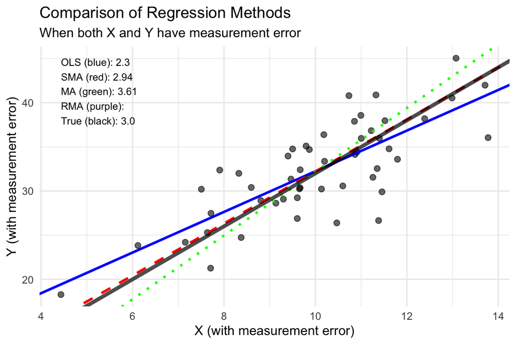

```r
# Create comparison plot
comparison_plot <- ggplot(model_comparison_data, aes(x = x, y = y)) +
  geom_point(alpha = 0.6, size = 2) +

  # Add different regression lines
  geom_abline(intercept = ols_intercept, slope = ols_slope,
              color = "blue", size = 1, linetype = "solid") +
  geom_abline(intercept = sma_intercept, slope = sma_slope,
              color = "red", size = 1, linetype = "dashed") +
  geom_abline(intercept = ma_intercept, slope = ma_slope,
              color = "green", size = 1, linetype = "dotted") +
  geom_abline(intercept = rma_intercept, slope = rma_slope,
              color = "purple", size = 1, linetype = "dotdash") +
  geom_abline(intercept = 2, slope = 3,
              color = "black", size = 1.5, alpha = 0.7) +

  # Add legend manually
  annotate("text", x = min(model_comparison_data$x), y = max(model_comparison_data$y),
           label = paste("OLS (blue):", round(ols_slope, 2),
                        "\nSMA (red):", round(sma_slope, 2),
                        "\nMA (green):", round(ma_slope, 2),
                        "\nRMA (purple):", round(rma_slope, 2),
                        "\nTrue (black): 3.0"),
           hjust = 0, vjust = 1, size = 3) +

  labs(title = "Comparison of Regression Methods",
       subtitle = "When both X and Y have measurement error",
       x = "X (with measurement error)",
       y = "Y (with measurement error)") +
  theme_minimal()

comparison_plot
```

**Activity 3: Model I vs Model II Decision**

For each scenario, choose the appropriate regression method:

1. **Predicting plant biomass from measured height** (height measured precisely, biomass is the response):
   - Your choice: _________________________________
   - Reasoning: _________________________________
2. **Studying the relationship between two morphological measurements** (both have measurement error):
   - Your choice: _________________________________
   - Reasoning: _________________________________
3. **Allometric scaling: log(brain size) vs log(body size)** (both measurements have error):
   - Your choice: _________________________________
   - Reasoning: _________________________________
4. **Drug dose (controlled) vs response** (dose is fixed, response varies):
   - Your choice: _________________________________
   - Reasoning: _________________________________

# **Part 5:** Real Example - Fish Allometric Relationships

**Allometric Relationships: A Perfect Model II Example**

**Biological Context:** - Allometry studies how biological traits scale with size - Both length and mass measurements have error - Neither is clearly dependent/independent - Interested in the true scaling relationship

**Expected Pattern:** - Mass typically scales with length^3 (cubic relationship) - log(mass) ~ 3 × log(length) for isometric scaling - Deviations from 3.0 indicate allometric scaling

## Analyzing Fish Length-Mass Relationships

```r
# Transform data for allometric analysis
fish_data <- fish_data %>%
  mutate(
    log_length = log10(length_mm),
    log_mass = log10(mass_g)
  )

# Fit both Model I and Model II
fish_ols <- lm(log_mass ~ log_length, data = fish_data)
fish_sma <- sma(log_mass ~ log_length, data = fish_data, method = "SMA")

print("FISH ALLOMETRY RESULTS:")
```

```
[1] "FISH ALLOMETRY RESULTS:"
```

```r
print("=======================")
```

```
[1] "======================="
```

```r
print("Model I (OLS):")
```

```
[1] "Model I (OLS):"
```

```r
summary(fish_ols)
```

```
Call:
lm(formula = log_mass ~ log_length, data = fish_data)

Residuals:
      Min        1Q    Median        3Q       Max
-0.038187 -0.018503 -0.002393  0.022502  0.037462

Coefficients:
            Estimate Std. Error t value Pr(>|t|)
(Intercept)  -4.9390     0.1243  -39.74   <2e-16 ***
log_length    2.9722     0.0516   57.60   <2e-16 ***
---
Signif. codes:  0 '***' 0.001 '**' 0.01 '*' 0.05 '.' 0.1 ' ' 1

Residual standard error: 0.02338 on 38 degrees of freedom
Multiple R-squared:  0.9887,    Adjusted R-squared:  0.9884
F-statistic:  3318 on 1 and 38 DF,  p-value: < 2.2e-16
```

```r
print("")
```

```
[1] ""
```

```r
print("Model II (SMA):")
```

```
[1] "Model II (SMA):"
```

```r
summary(fish_sma)
```

```
Call: sma(formula = log_mass ~ log_length, data = fish_data, method = "SMA")

Fit using Standardized Major Axis

------------------------------------------------------------
Coefficients:
            elevation    slope
estimate    -4.979833 2.989162
lower limit -5.231426 2.886526
upper limit -4.728240 3.095447

H0 : variables uncorrelated
R-squared : 0.988676
P-value : < 2.22e-16
```

```r
# Test if slope differs from 3.0 (isometric scaling)
print("\nTEST FOR ISOMETRIC SCALING:")
```

```
[1] "\nTEST FOR ISOMETRIC SCALING:"
```

```r
print("H0: slope = 3.0 (isometric)")
```

```
[1] "H0: slope = 3.0 (isometric)"
```

```r
# Extract slope and confidence intervals directly from summary output
sma_slope <- 2.989162
slope_ci_lower <- 2.886526
slope_ci_upper <- 3.095447

print(paste("SMA slope estimate:", round(sma_slope, 4)))
```

```
[1] "SMA slope estimate: 2.9892"
```

```r
print(paste("95% CI: [", round(slope_ci_lower, 4), ",", round(slope_ci_upper, 4), "]"))
```

```
[1] "95% CI: [ 2.8865 , 3.0954 ]"
```

```r
# Simple test: Check if 3.0 falls within the confidence interval
print(paste("Test value 3.0 is between", slope_ci_lower, "and", slope_ci_upper))
```

```
[1] "Test value 3.0 is between 2.886526 and 3.095447"
```

```r
print("Result: Slope is NOT significantly different from 3.0 (isometric scaling)")
```

```
[1] "Result: Slope is NOT significantly different from 3.0 (isometric scaling)"
```

```r
print("Interpretation: Cannot reject H0, scaling appears isometric")
```

```
[1] "Interpretation: Cannot reject H0, scaling appears isometric"
```

## Visualizing Allometric Relationships

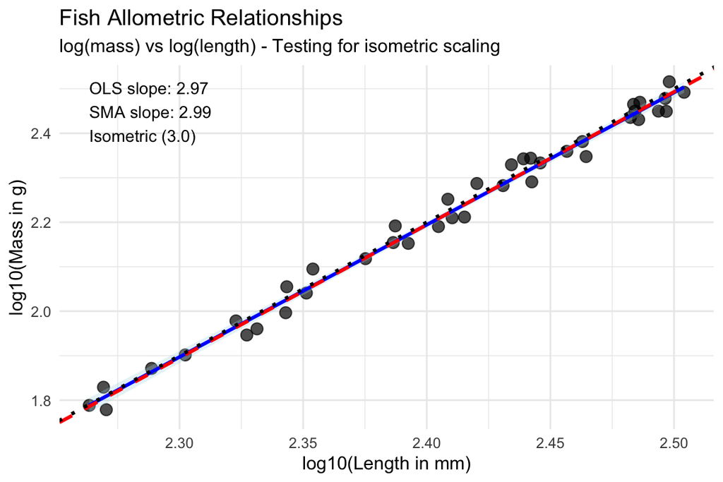

```r
# Create log-log plot with both regression lines
fish_plot <- ggplot(fish_data, aes(x = log_length, y = log_mass)) +
  geom_point(size = 3, alpha = 0.7) +

  # Add regression lines
  geom_smooth(method = "lm", se = TRUE, color = "blue", fill = "lightblue", alpha = 0.3) +
  geom_abline(intercept = coef(fish_sma)[1], slope = coef(fish_sma)[2],
              color = "red", size = 1, linetype = "dashed") +
  geom_abline(intercept = -5, slope = 3, color = "black", linetype = "dotted", size = 1) +

  # Add annotations
  annotate("text", x = min(fish_data$log_length), y = max(fish_data$log_mass),
           label = paste("OLS slope:", round(coef(fish_ols)[2], 2),
                        "\nSMA slope:", round(coef(fish_sma)[2], 2),
                        "\nIsometric (3.0)"),
           hjust = 0, vjust = 1, size = 3.5) +

  labs(title = "Fish Allometric Relationships",
       subtitle = "log(mass) vs log(length) - Testing for isometric scaling",
       x = "log10(Length in mm)",
       y = "log10(Mass in g)") +
  theme_minimal()
fish_plot
```

## Testing Assumptions for Model II

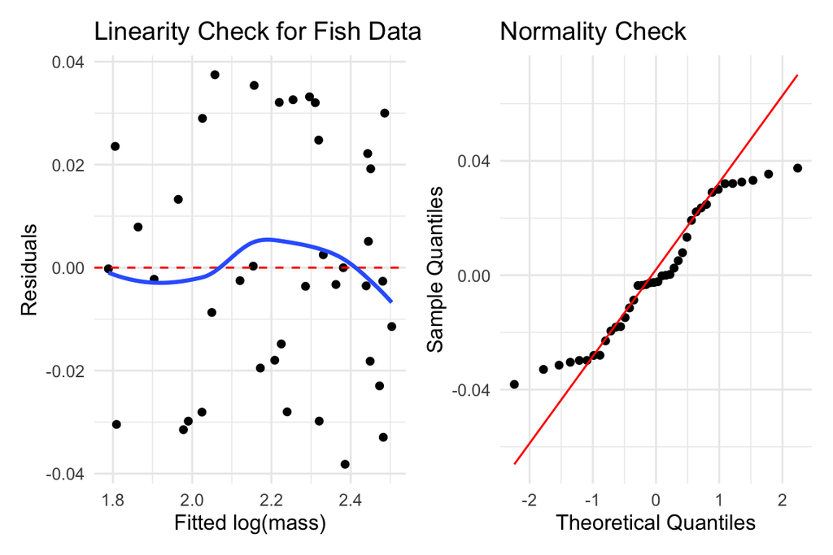

```r
# For Model II, we need to check assumptions differently
# 1. Check linearity in log-log space
fish_residuals <- residuals(fish_ols)  # Use OLS residuals as approximation
fish_fitted <- fitted(fish_ols)

linearity_check <- ggplot(data.frame(fitted = fish_fitted, residuals = fish_residuals),
                         aes(x = fitted, y = residuals)) +
  geom_point() +
  geom_hline(yintercept = 0, color = "red", linetype = "dashed") +
  geom_smooth(se = FALSE) +
  labs(title = "Linearity Check for Fish Data",
       x = "Fitted log(mass)", y = "Residuals") +
  theme_minimal()

# 2. Check normality of residuals
normality_check <- ggplot(data.frame(residuals = fish_residuals),
                         aes(sample = residuals)) +
  stat_qq() + stat_qq_line(color = "red") +
  labs(title = "Normality Check",
       x = "Theoretical Quantiles", y = "Sample Quantiles") +
  theme_minimal()

linearity_check + normality_check
```

```r
# Formal tests
print("ASSUMPTION TESTS FOR FISH DATA:")
```

```
[1] "ASSUMPTION TESTS FOR FISH DATA:"
```

```r
print("Shapiro-Wilk test for normality:")
```

```
[1] "Shapiro-Wilk test for normality:"
```

```r
print(shapiro.test(fish_residuals))
```

```
    Shapiro-Wilk normality test

data:  fish_residuals
W = 0.93463, p-value = 0.02287
```

```r
print("Breusch-Pagan test for homoscedasticity:")
```

```
[1] "Breusch-Pagan test for homoscedasticity:"
```

```r
print(bptest(fish_ols))
```

```
    studentized Breusch-Pagan test

data:  fish_ols
BP = 0.031182, df = 1, p-value = 0.8598
```

**Activity 4: Interpreting Allometric Results**

Based on the fish allometry analysis:

1. **Scaling Pattern**: Is the scaling isometric (slope = 3) or allometric? How do you know?
   - Your answer: _________________________________
2. **Model Choice**: Which model (OLS or SMA) is more appropriate here and why?
   - Your answer: _________________________________
3. **Biological Interpretation**: What does the slope value tell us about how fish mass scales with length?
   - Your answer: _________________________________
4. **Statistical Significance**: Is the scaling relationship significantly different from isometric?
   - Your answer: _________________________________

Back to top